# Aula 12 - Análise de Variância

3/11/2022

Para a base de dados **salario.csv**, verifique se exise diferença entre as médias salariais dos grupos: (1) efetue a ANOVA; (2) plote os diagramas de caixa (boxplot); (3) efetue testes *post hoc*; (4) efetue a regressão linear com variáveis *dummy*; (5) comente os resultados encontrados.

Primeiro vamos ler a base de dados:

```r
df = read.csv2('salario.csv', dec = ',')
df$grupo = as.factor(df$grupo)
```

1. efetue a ANOVA:

```r
summary(aov(salario ~ grupo, df))
```

```
##                Df    Sum Sq   Mean Sq F value Pr(>F)
## grupo           3 3.982e+09 1.327e+09   686.4 <2e-16 ***
## Residuals   19996 3.866e+10 1.934e+06
## ---
## Signif. codes:  0 '***' 0.001 '**' 0.01 '*' 0.05 '.' 0.1 ' ' 1
```

2. plote os diagramas de caixa:

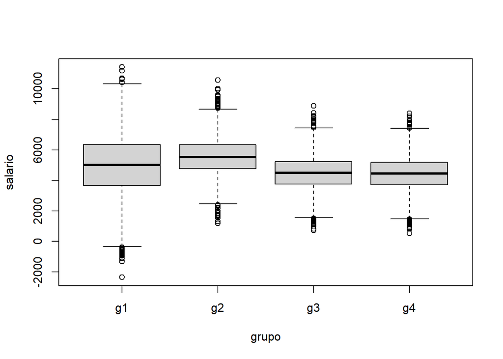

```r
boxplot(salario ~ grupo, df)
```

3. efetue testes *post hoc*:

```r
pairwise.t.test(df$salario, df$grupo, paired = FALSE, p.adjust.method = "bonferroni")
```

```
##
##  Pairwise comparisons using t tests with pooled SD
##
## data:  df$salario and df$grupo
##
##    g1     g2     g3
## g2 <2e-16 -      -
## g3 <2e-16 <2e-16 -
## g4 <2e-16 <2e-16 0.53
##
## P value adjustment method: bonferroni
```

4. efetue a regressão linear com variáveis dummy:

```r
summary(lm(salario ~ grupo, df))
```

```
##
## Call:
## lm(formula = salario ~ grupo, data = df)
##
## Residuals:
##     Min      1Q  Median      3Q     Max
## -7351.2  -863.0     0.7   864.9  6429.8
##
## Coefficients:
##             Estimate Std. Error t value Pr(>|t|)
## (Intercept)  4994.01      19.67  253.95   <2e-16 ***
## grupog2       547.34      27.81   19.68   <2e-16 ***
## grupog3      -506.05      27.81  -18.20   <2e-16 ***
## grupog4      -553.43      27.81  -19.90   <2e-16 ***
## ---
## Signif. codes:  0 '***' 0.001 '**' 0.01 '*' 0.05 '.' 0.1 ' ' 1
##
## Residual standard error: 1391 on 19996 degrees of freedom
## Multiple R-squared:  0.09337,    Adjusted R-squared:  0.09323
## F-statistic: 686.4 on 3 and 19996 DF,  p-value: < 2.2e-16
```

5. comente os resultados encontrados:

Em todas essas alternativas o que estamos fazendo é checando se as médias dos grupos são diferentes.

O boxplot (item 2) faz isso visualmente, dividindo a dispersão dos salários em cada grupo. Visualmente podemos observar que os grupos 3 e 4 possuem dispersões e médias parecidas.

Na regressão (item 4), relacionamos o valor do salário de acordo com o grupo. Nesse exemplo, como o nível base é o grupo g1, podemos ver que a média é de 4994 (valor do intercepto) e que as médias dos outros grupos é o intercepto adicionado com o valor do coeficiente do grupo específico. O que vimos no boxplot (grupos 3 e 4 parecidos) podemos ver aqui também ao observar que o valor dos coeficientes dos grupos 3 e 4 é próximo (diferença de 50 unidades onde as observações médias são da ordem de 5000 unidades).

No ANOVA (item 1), é feita uma comparação da variação total do grupo com todos os dados e da variação em cada grupo. O resultado do ANOVA é que ou todas as médias são iguais ou pelo menos uma das médias dos grupos é diferente. Nesse caso, vimos no resultado que pelo menos uma das médias do 4 grupos são diferentes.

Nos testes post hoc é feita uma comparação grupo a grupo. No exemplo acima (item 3), podemos observar que há diferenças entre as médias dos grupos g1 e g2, g1 e g3, g1 e g4, g2 e g3, g2 e g4. Entretanto não há diferença entre as médias dos grupos g3 e g4.